# Hypothesis Testing in R

郭耀仁 Yao-Jen Kuo

2019-11-13

## Agenda

- What is Hypothesis Testing
- Types of Error
- A Recap of Kaggle Dataset: Titanic
- Lower Tail Test of Population Mean with Known Variance
- Upper Tail Test of Population Mean with Known Variance
- Two-Tailed Test of Population Mean with Known Variance
- Lower Tail Test of Population Mean with Unknown Variance
- Upper Tail Test of Population Mean with Unknown Variance
- Two-Tailed Test of Population Mean with Unknown Variance

# What is Hypothesis Testing

## Researchers retain or reject hypothesis based on measurements of observed samples

## To determine whether retain or reject is based on “Hypothesis Testing”

## How to state the hypotheses

- Null hypothesis: an assumption that is made about the larger population, denoted by $H_0$
- Alternative hypothesis: negates the null hypothesis, denoted by $H_1$ or $H_a$

## For example: Is my coin fair?

- Null hypothesis: there would be an equal number of occurrences of heads and tails if a coin is tossed several times(a fair coin!)
- Alternative hypothesis: the occurrences of heads and tails would have significant differences if a coin is tossed several times(an unfair coin!)

## Tossing a fair coin for 100 times

```r
set.seed(87)
coin_toss <- sample(c("Tail", "Head"), size = 100, replace = TRUE)
```

## The $z$ statistic

```r
n_of_heads <- sum(coin_toss == "Head")
p_heads <- n_of_heads / length(coin_toss)
p_0 <- 0.5
n <- length(coin_toss)
z <- (p_heads - p_0) / sqrt(p_0*(1-p_0)/n)
z
```

```
## [1] 0.2
```

## The $z_{-\alpha/2}$ and $z_{\alpha/2}$

```r
alpha = .05
z_half_alpha <- qnorm(1 - alpha/2)
c(-z_half_alpha, z_half_alpha)
```

```
## [1] -1.959964  1.959964
```

## Interpretation

The test statistic 0.2 which lies between the critical values of -1.959964 and 1.959964. Hence, at .05 significance level, we do not reject the claim that our coin is fair. Say, our coin is fair.

## Tossing an unfair coin for 100 times

```r
set.seed(87)
coin_toss <- sample(c("Tail", "Head"), size = 100, replace = TRUE, prob = c(0.3, 0.7))
```

## The $z$ statistic

```r
n_of_heads <- sum(coin_toss == "Head")
p_heads <- n_of_heads / length(coin_toss)
p_0 <- 0.5
n <- length(coin_toss)
z <- (p_heads - p_0) / sqrt(p_0*(1-p_0)/n)
z
```

```
## [1] 4.4
```

## The $z_{-\alpha/2}$ and $z_{\alpha/2}$

```r
alpha = .05
z_half_alpha <- qnorm(1 - alpha/2)
c(-z_half_alpha, z_half_alpha)
```

```
## [1] -1.959964  1.959964
```

## Interpretation

The test statistic 4.4 which lies outside of the critical values of -1.959964 and 1.959964. Hence, at .05 significance level, we reject the claim that our coin is fair. Say, our coin is unfair.

# Types of error

## There are 2 types of error might occur after we decided to accept or reject null hypothesis

1. **Type I error**: falsely rejecting a TRUE $H_0$
2. **Type II error**: falsely accepting a FALSE $H_0$

## Understanding these 2 errors via confusion matrix

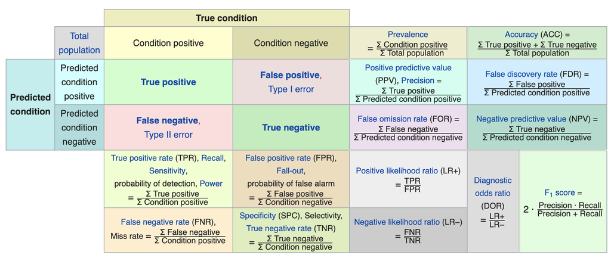

## In confusion matrix

- Positive refers to rejecting hypothesis
- Negative refers to accepting hypothesis

## There are 4 possible combinations

1. TP: truly rejecting a FALSE $H_0$
2. TN: truly accepting a TRUE $H_0$
3. FP: falsely rejecting a TRUE $H_0$ **Type I error**
4. FN: falsely accepting a FALSE $H_0$ **Type II error**

## If confusion matrix makes you too confused…this might help

## Null hypothesis: Not pregnant

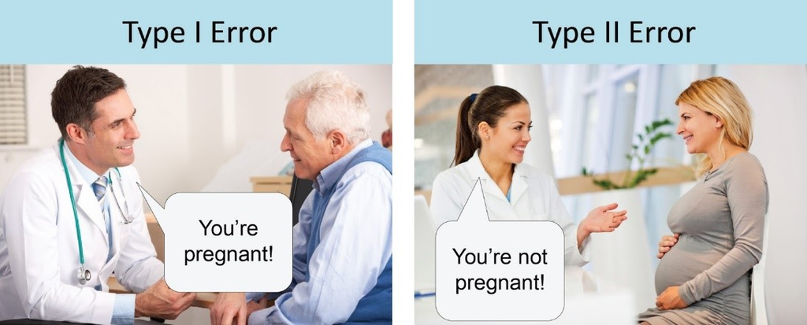

## The probability of committing decision errors

- The probability of committing a Type I Error is denoted by $\alpha$
- The probability of committing a Type II Error is denoted by $\beta$

# A Recap of Kaggle Dataset: Titanic

## Dataset description of Titanic

https://www.kaggle.com/c/titanic

## The Titanic dataset

```r
titanic <- read.csv("https://kaggle-getting-started.s3-ap-northeast-1.amazonaws.com/titanic/train.csv", stringsAsFactors = FALSE)
dim(titanic)
```

```
## [1] 891  12
```

```r
summary(titanic)
```

```
##   PassengerId       Survived          Pclass          Name
##  Min.   :  1.0   Min.   :0.0000   Min.   :1.000   Length:891
##  1st Qu.:223.5   1st Qu.:0.0000   1st Qu.:2.000   Class :character
##  Median :446.0   Median :0.0000   Median :3.000   Mode  :character
##  Mean   :446.0   Mean   :0.3838   Mean   :2.309
##  3rd Qu.:668.5   3rd Qu.:1.0000   3rd Qu.:3.000
##  Max.   :891.0   Max.   :1.0000   Max.   :3.000
##
##      Sex                 Age            SibSp           Parch
##  Length:891         Min.   : 0.42   Min.   :0.000   Min.   :0.0000
##  Class :character   1st Qu.:20.12   1st Qu.:0.000   1st Qu.:0.0000
##  Mode  :character   Median :28.00   Median :0.000   Median :0.0000
##                     Mean   :29.70   Mean   :0.523   Mean   :0.3816
##                     3rd Qu.:38.00   3rd Qu.:1.000   3rd Qu.:0.0000
##                     Max.   :80.00   Max.   :8.000   Max.   :6.0000
##                     NA's   :177
##     Ticket               Fare           Cabin             Embarked
##  Length:891         Min.   :  0.00   Length:891         Length:891
##  Class :character   1st Qu.:  7.91   Class :character   Class :character
##  Mode  :character   Median : 14.45   Mode  :character   Mode  :character
##                     Mean   : 32.20
##                     3rd Qu.: 31.00
##                     Max.   :512.33
##
```

## Removing rows with NAs

```r
titanic <- titanic[complete.cases(titanic), ]
dim(titanic)
```

```
## [1] 714  12
```

```r
summary(titanic)
```

```
##   PassengerId       Survived          Pclass          Name
##  Min.   :  1.0   Min.   :0.0000   Min.   :1.000   Length:714
##  1st Qu.:222.2   1st Qu.:0.0000   1st Qu.:1.000   Class :character
##  Median :445.0   Median :0.0000   Median :2.000   Mode  :character
##  Mean   :448.6   Mean   :0.4062   Mean   :2.237
##  3rd Qu.:677.8   3rd Qu.:1.0000   3rd Qu.:3.000
##  Max.   :891.0   Max.   :1.0000   Max.   :3.000
##      Sex                 Age            SibSp            Parch
##  Length:714         Min.   : 0.42   Min.   :0.0000   Min.   :0.0000
##  Class :character   1st Qu.:20.12   1st Qu.:0.0000   1st Qu.:0.0000
##  Mode  :character   Median :28.00   Median :0.0000   Median :0.0000
##                     Mean   :29.70   Mean   :0.5126   Mean   :0.4314
##                     3rd Qu.:38.00   3rd Qu.:1.0000   3rd Qu.:1.0000
##                     Max.   :80.00   Max.   :5.0000   Max.   :6.0000
##     Ticket               Fare           Cabin             Embarked
##  Length:714         Min.   :  0.00   Length:714         Length:714
##  Class :character   1st Qu.:  8.05   Class :character   Class :character
##  Mode  :character   Median : 15.74   Mode  :character   Mode  :character
##                     Mean   : 34.69
##                     3rd Qu.: 33.38
##                     Max.   :512.33
```

## Updating row indice

```r
row.names(titanic) <- NULL
```

## The Built-In `var()` and `sd()` Functions uses denominator of `n-1`

```r
?var
?sd
```

## Creating our own functions for population variance and standard deviation

```r
population_var <- function(x) {
  n <- length(x)
  mu <- mean(x)
  error <- x - mu
  squared_error <- error**2
  sum_squared_error <- sum(squared_error)
  return(sum_squared_error / n)
}

population_sd <- function(x) {
  pop_var <- population_var(x)
  return(sqrt(pop_var))
}
```

## Getting our samples

```r
set.seed(87)
row_indice <- as.numeric(rownames(titanic))
sampled_row_indice <- sample(row_indice, size = 30)
sampled_titanic <- titanic[sampled_row_indice, ]
sample_mean_age <- mean(sampled_titanic$Age)
sample_mean_age
```

```
## [1] 31.28333
```

# Lower Tail Test of Population Mean with Known Variance

## Null hypothesis of the lower tail test of the population mean

$$\mu \ge \mu_0$$

## The test statistic $z$

$$z = \frac{\bar{x} - \mu_0}{\sigma/\sqrt{n}}$$

The null hypothesis of the lower tail test is to be rejected if $z \le -z_{\alpha}$

## The picture of lower tail test

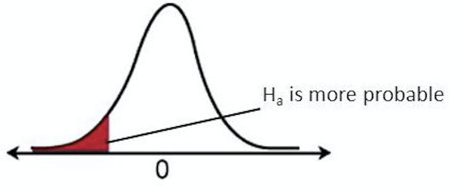

## Problem

Suppose the historian claims that the mean age of Titanic passengers is older than 40 years old. In a sample of 30 passengers, it was found that they are 31.2833333 years old on average. At .05 significance level, can we reject the claim by the historian?

## Solution

```r
x_bar <- sample_mean_age
mu_0 <- 40
sigma <- population_sd(titanic$Age)
n <- 30
z <- (x_bar - mu_0)/(sigma/sqrt(n))
z
```

```
## [1] -3.288929
```

```r
alpha <- .05
z_alpha <- qnorm(1 - alpha)
-z_alpha
```

```
## [1] -1.644854
```

## Interpretation

The test statistic -3.288929 is less than the critical value of -1.6448536. Hence, at .05 significance level, we reject the claim that mean age of Titanic passengers is older than 40 years old.

# Upper Tail Test of Population Mean with Known Variance

## Null hypothesis of the upper tail test of the population mean

$$\mu \le \mu_0$$

## The test statistic $z$

$$z = \frac{\bar{x} - \mu_0}{\sigma/\sqrt{n}}$$

The null hypothesis of the upper tail test is to be rejected if $z \ge z_{\alpha}$

## The picture of upper tail test

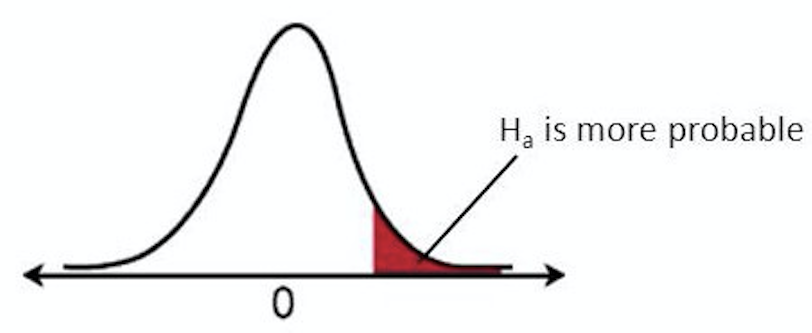

## Problem

Suppose the historian claims that the mean age of Titanic passengers is younger than 20 years old. In a sample of 30 passengers, it was found that they are 31.2833333 years old on average. At .05 significance level, can we reject the claim by the historian?

## Solution

```r
x_bar <- sample_mean_age
mu_0 <- 20
sigma <- population_sd(titanic$Age)
n <- 30
z <- (x_bar - mu_0)/(sigma/sqrt(n))
z
```

```
## [1] 4.257371
```

```r
alpha <- .05
z_alpha <- qnorm(1 - alpha)
z_alpha
```

```
## [1] 1.644854
```

## Interpretation

The test statistic 4.2573708 is greater than the critical value of 1.6448536. Hence, at .05 significance level, we reject the claim that mean age of Titanic passengers is younger than 20 years old.

# Two-Tailed Test of Population Mean with Known Variance

## Null hypothesis of the two-tailed test of the population mean

$$\mu = \mu_0$$

## The test statistic $z$

$$z = \frac{\bar{x} - \mu_0}{\sigma/\sqrt{n}}$$

The null hypothesis of the two-tailed test is to be rejected if $z \le -z_{\alpha/2}$ or $z \ge z_{\alpha/2}$

## The picture of two-tailed test

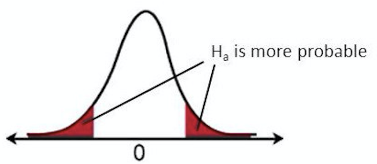

## Problem

Suppose the historian claims that the mean age of Titanic passengers in a sample of 30 passengers is the same as population, it was found that they are 31.2833333 years old on average. At .05 significance level, can we reject the claim by the historian?

## Solution

```r
x_bar <- sample_mean_age
mu_0 <- mean(titanic$Age)
sigma <- population_sd(titanic$Age)
n <- 30
z <- (x_bar - mu_0)/(sigma/sqrt(n))
z
```

```
## [1] 0.5977483
```

```r
alpha <- .05
z_half_alpha <- qnorm(1 - alpha/2)
c(-z_half_alpha, z_half_alpha)
```

```
## [1] -1.959964  1.959964
```

## Interpretation

The test statistic 0.5977483 which lies between the critical values of -1.959964 and 1.959964. Hence, at .05 significance level, we do not reject the claim that the sample mean age of Titanic passengers is the same as population.

## Exercise

> Suppose the historian claims that the mean fare of Titanic passengers in a sample of 30 passengers paid more than 40, it was found that they paid 36.0100033 on average. At .05 significance level, can we reject the claim by the historian?

# Lower Tail Test of Population Mean with Unknown Variance

## Null hypothesis of the lower tail test of the population mean

$$\mu \ge \mu_0$$

## The test statistic $t$

$$t = \frac{\bar{x} - \mu_0}{s/\sqrt{n}}$$

The null hypothesis of the lower tail test is to be rejected if $t \le -t_{\alpha}$

## The picture of lower tail test

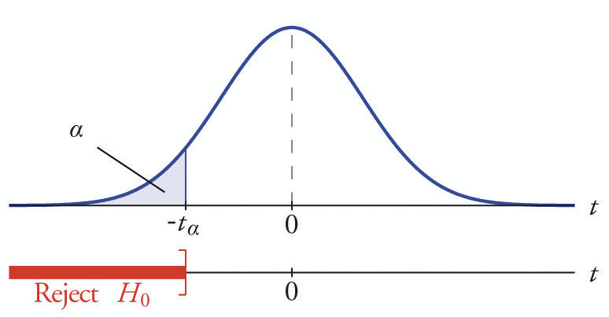

## Problem

Suppose the historian claims that the mean age of Titanic passengers is older than 40 years old. In a sample of 30 passengers, it was found that they are 31.2833333 years old on average. At .05 significance level, can we reject the claim by the historian?

## Solution

```r
x_bar <- sample_mean_age
mu_0 <- 40
s <- sd(sampled_titanic$Age)
n <- 30
t <- (x_bar - mu_0)/(s/sqrt(n))
t
```

```
## [1] -4.665509
```

```r
alpha <- .05
t_alpha <- qt(1 - alpha, df = n - 1)
-t_alpha
```

```
## [1] -1.699127
```

## Interpretation

The test statistic -4.6655086 is less than the critical value of -1.699127. Hence, at 0.05 significance level, we reject the claim that mean age of Titanic passengers is older than 40 years old.

# Upper Tail Test of Population Mean with Unknown Variance

## Null hypothesis of the upper tail test of the population mean

$$\mu \le \mu_0$$

## The test statistic $t$

$$t = \frac{\bar{x} - \mu_0}{s/\sqrt{n}}$$

The null hypothesis of the upper tail test is to be rejected if $t \ge t_{\alpha}$

## The picture of upper tail test

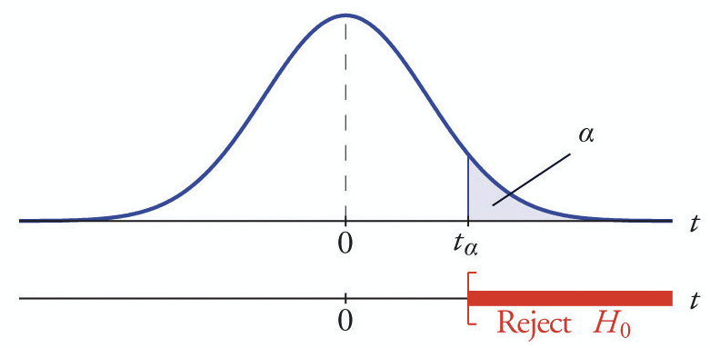

## Problem

Suppose the historian claims that the mean age of Titanic passengers is younger than 20 years old. In a sample of 30 passengers, it was found that they are 31.2833333 years old on average. At .05 significance level, can we reject the claim by the historian?

## Solution

```r
x_bar <- sample_mean_age
mu_0 <- 20
s <- sd(sampled_titanic$Age)
n <- 30
t <- (x_bar - mu_0)/(s/sqrt(n))
t
```

```
## [1] 6.039291
```

```r
alpha <- .05
t_alpha <- qt(1 - alpha, df = n - 1)
t_alpha
```

```
## [1] 1.699127
```

## Interpretation

The test statistic 6.0392912 is greater than the critical value of 1.699127. Hence, at .05 significance level, we reject the claim that mean age of Titanic passengers is younger than 20 years old.

# Two-Tailed Test of Population Mean with Unknown Variance

## Null hypothesis of the two-tailed test of the population mean

$$\mu = \mu_0$$

## The test statistic $t$

$$t = \frac{\bar{x} - \mu_0}{s/\sqrt{n}}$$

The null hypothesis of the two-tailed test is to be rejected if $t \le -t_{\alpha/2}$ or $t \ge t_{\alpha/2}$

## The picture of two-tailed test

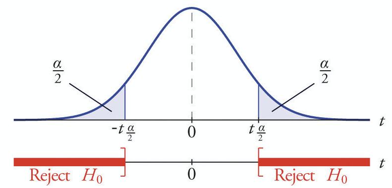

## Problem

Suppose the historian claims that the mean age of Titanic passengers in a sample of 30 passengers is the same as population, it was found that they are 31.2833333 years old on average. At .05 significance level, can we reject the claim by the historian?

## Solution

```r
x_bar <- sample_mean_age
mu_0 <- mean(titanic$Age)
s <- sd(sampled_titanic$Age)
n <- 30
t <- (x_bar - mu_0)/(s/sqrt(n))
t
```

```
## [1] 0.8479356
```

```r
alpha <- .05
t_half_alpha <- qt(1 - alpha/2, df = n - 1)
c(-t_half_alpha, t_half_alpha)
```

```
## [1] -2.04523  2.04523
```

## Interpretation

The test statistic 0.8479356 which lies between the critical values of -2.0452296 and 2.0452296. Hence, at .05 significance level, we do not reject the claim that the sample mean age of Titanic passengers is the same as population.

## Exercise

> Suppose the historian claims that the mean fare of Titanic passengers in a sample of 30 passengers from `Pclass == 1` is the same as `Pclass == 3`. At .05 significance level, can we reject the claim by the historian? (Use `set.seed(87)` while sampling)